# Sieci konwolucyjne, część II

W drugiej części należało wykorzystać zbiór cifar10 i sprawdzić na nim działanie najlepszego modelu z pierwszej części oraz jego modyfikacji.

# Dane

W zbiorze cifar10 mamy doczynienia z problemem klasyfikacji obrazów do 10 poniższych klas:

```python
# ful code in notebooks
```

```
{0: 'airplane',
 1: 'automobile',
 2: 'bird',
 3: 'cat',
 4: 'deer',
 5: 'dog',
 6: 'frog',
 7: 'horse',
 8: 'ship',
 9: 'truck'}
```

Przykładowe obrazy:

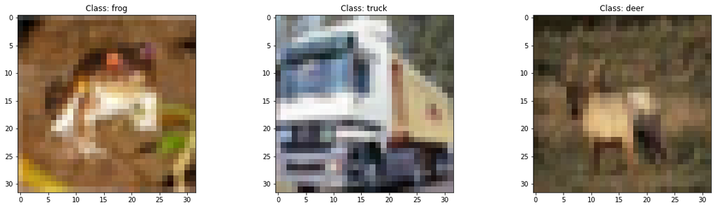

```python
# ful code in notebooks
```

W zbiorze treningowym znalazło się 50000 obrazów, natomiat w zbiorze waldiacyjnym i testowym po 5000 obrazów.

```python
# ful code in notebooks
```

```
Trainnig data shape:
(50000, 32, 32, 3)
Valdiation data shape:
(5000, 32, 32, 3)
Test data shape:
(5000, 32, 32, 3)
```

Zbiory są całkowicie zbalansowane:

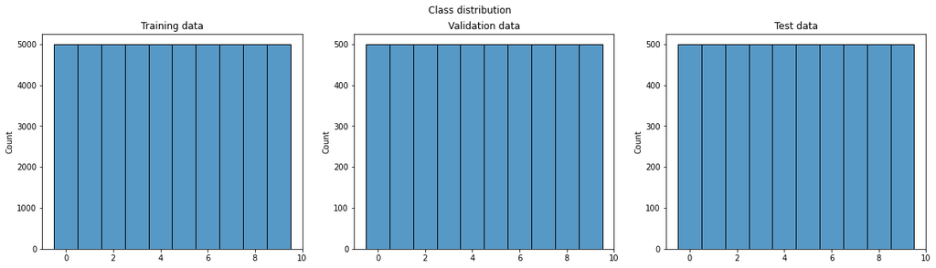

```python
# ful code in notebooks
```

## Modele

Pierwsyzm modelem jest najlepszy model z części pierwszej, a zbadane modyfikacje to:

```python
class Model1:
  def __init__(self):

    self.model = models.Sequential()
    self.model.add(layers.Conv2D(64, (5, 5), activation='relu', input_shape=(32, 32, 3)))
    self.model.add(layers.MaxPooling2D((2, 2), strides=(2, 2)))
    self.model.add(layers.Conv2D(64, (5, 5), activation='relu', input_shape=(32, 32, 64)))
    self.model.add(layers.MaxPooling2D((2, 2), strides=(2, 2)))
    self.model.add(layers.Flatten())
    self.model.add(layers.Dense(384, activation='relu'))
    self.model.add(layers.Dense(192, activation='relu'))
    self.model.add(layers.Dense(14, activation='softmax'))

    self.name = 'Model1'
    self.history = None
    self.params = None


class Model2:
  def __init__(self):

    self.model = models.Sequential()
    self.model.add(layers.Conv2D(64, (5, 5), activation='relu', input_shape=(32, 32, 3)))
    self.model.add(layers.MaxPooling2D((2, 2), strides=(2, 2)))
    self.model.add(layers.Conv2D(64, (5, 5), activation='relu', input_shape=(32, 32, 64)))
    self.model.add(layers.MaxPooling2D((2, 2), strides=(2, 2)))
    self.model.add(layers.Flatten())
    self.model.add(layers.Dense(384, activation='relu'))
    self.model.add(layers.Dropout(.1))
    self.model.add(layers.Dense(192, activation='relu'))
    self.model.add(layers.Dropout(.1))
    self.model.add(layers.Dense(14, activation='softmax'))

    self.name = 'Model2_dropout'
    self.history = None
    self.params = None


class Model3:
  def __init__(self):

    self.model = models.Sequential()
    self.model.add(layers.Conv2D(64, (5, 5), activation='relu', input_shape=(32, 32, 3)))
    self.model.add(layers.MaxPooling2D((2, 2), strides=(2, 2)))
    self.model.add(layers.Conv2D(64, (5, 5), activation='relu', input_shape=(32, 32, 64)))
    self.model.add(layers.MaxPooling2D((2, 2), strides=(2, 2)))
    self.model.add(layers.Flatten())
    self.model.add(layers.Dense(384, activation='relu',  kernel_regularizer='l1'))
    self.model.add(layers.Dense(192, activation='relu',  kernel_regularizer='l1'))
    self.model.add(layers.Dense(14, activation='softmax'))

    self.name = 'Model3_l1'
    self.history = None
    self.params = None


class Model4:
  def __init__(self):

    self.model = models.Sequential()
    self.model.add(layers.DepthwiseConv2D((5, 5), activation='relu', input_shape=(32, 32, 3)))
    self.model.add(layers.MaxPooling2D((2, 2), strides=(2, 2)))
    self.model.add(layers.DepthwiseConv2D((5, 5), activation='relu', input_shape=(32, 32, 64)))
    self.model.add(layers.MaxPooling2D((2, 2), strides=(2, 2)))
    self.model.add(layers.Flatten())
    self.model.add(layers.Dense(384, activation='relu'))
    self.model.add(layers.Dense(192, activation='relu'))
    self.model.add(layers.Dense(14, activation='softmax'))

    self.name = 'Model4_depthwise'
    self.history = None
    self.params = None
```

## Uczenie

W procesie uczenia zastosowano njlepsze hiperparametry znalezione w porzedniej części:

- optymalizator: Adam,
- współczynnik uczenia: 0.001,
- rozmiar paczki: 500,
- liczba epok: 50.

Poniżej przedstawiono wyniki:

```python
# full code in notebooks
```

|  | index | model | optimizer | lr | epochs | batch | best_val_loss | best_val_acc | best_val_f1 |
| --- | --- | --- | --- | --- | --- | --- | --- | --- | --- |
| 1 | 1 | Model2_dropout | adam | 0.001 | 50 | 500 | 1.746912 | 0.7218 | 0.718965 |
| 0 | 0 | Model1 | adam | 0.001 | 50 | 500 | 2.322858 | 0.7082 | 0.704594 |
| 2 | 2 | Model3_l1 | adam | 0.001 | 50 | 500 | 4.385132 | 0.5498 | 0.538229 |
| 3 | 3 | Model4_depthwise | adam | 0.001 | 50 | 500 | 2.016536 | 0.5350 | 0.527053 |

Przebiegi wszystkich procesów znaleźć można w załączniku Zal_2.html

## Najlepszy model

Najlepsze wyniki dał model wykorzystujący technikę regularyzacji Dropout. Poniżej przedstawiono jego parametry i prebieg uczenia:

```
--------MODEL--------

Model2_dropout

Model: "sequential_7"
_________________________________________________________________
Layer (type)                 Output Shape              Param #
=================================================================
conv2d_10 (Conv2D)           (None, 28, 28, 64)        4864
_________________________________________________________________
max_pooling2d_13 (MaxPooling (None, 14, 14, 64)        0
_________________________________________________________________
conv2d_11 (Conv2D)           (None, 10, 10, 64)        102464
_________________________________________________________________
max_pooling2d_14 (MaxPooling (None, 5, 5, 64)          0
_________________________________________________________________
flatten_6 (Flatten)          (None, 1600)              0
_________________________________________________________________
dense_18 (Dense)             (None, 384)               614784
_________________________________________________________________
dropout_2 (Dropout)          (None, 384)               0
_________________________________________________________________
dense_19 (Dense)             (None, 192)               73920
_________________________________________________________________
dropout_3 (Dropout)          (None, 192)               0
_________________________________________________________________
dense_20 (Dense)             (None, 14)                2702
=================================================================
Total params: 798,734
Trainable params: 798,734
Non-trainable params: 0
_________________________________________________________________
None

Optimizer:  adam
Learning rate:  0.001
Epochs:  50
Batch:  500

Best validation Loss:  1.7469121217727661
Best validation Accuracy:  0.7218000292778015
Best validation F1Score:  0.7189649343490601
```

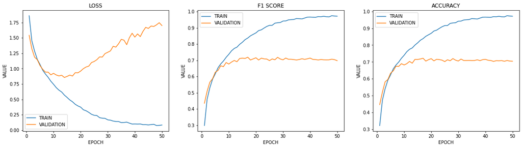

```python
# full code in notebooks
```

Wynik działania modelu na zbiorze testowym:

```python
# full code in notebooks
```

```
Test F1: 0.7011389180687719
```

Macierz pomyłek:

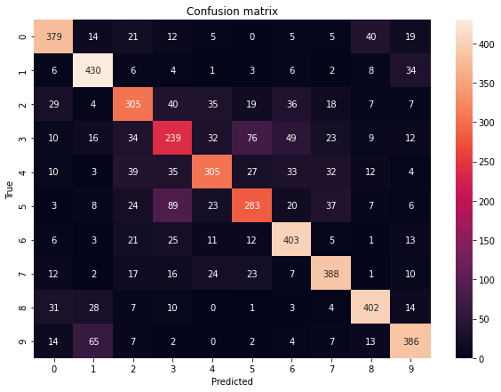

```python
# full code in notebooks
```

Przykłady błędnych klasyfikacji dla każdej z klas:

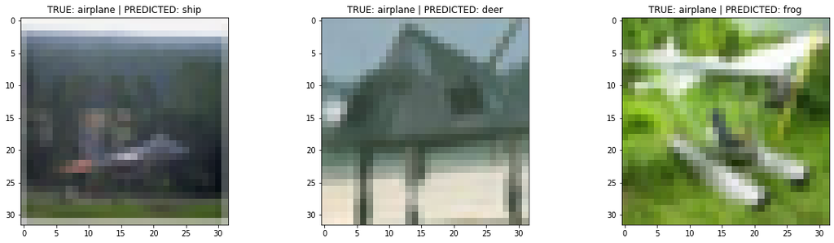

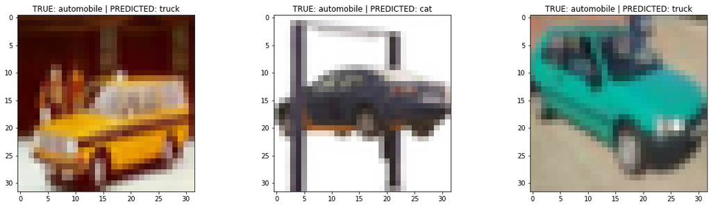

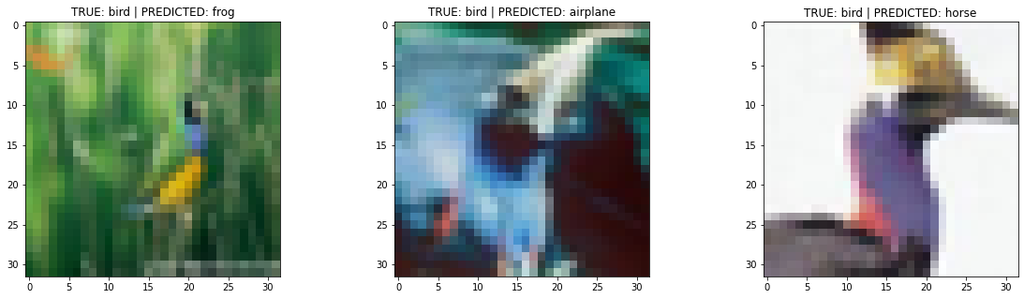

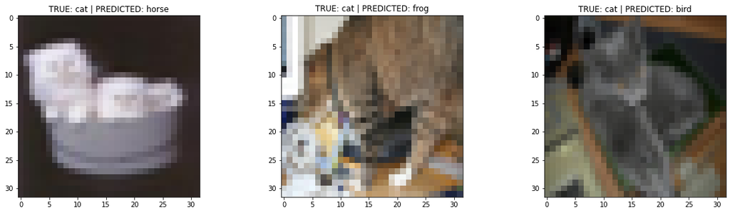

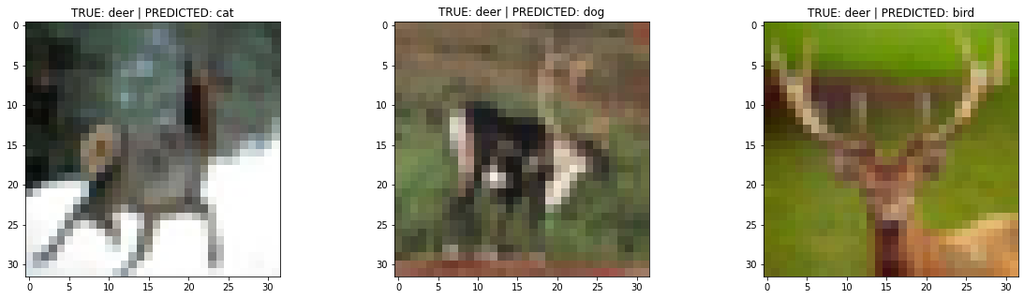

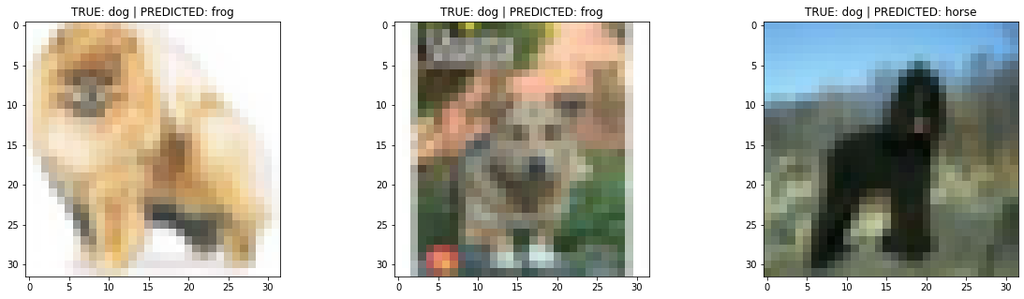

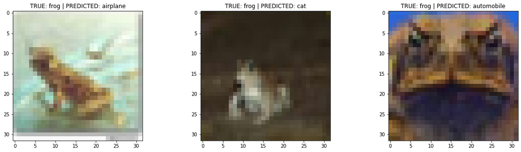

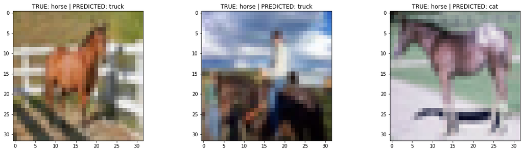

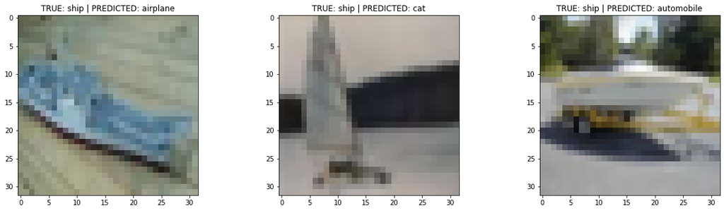

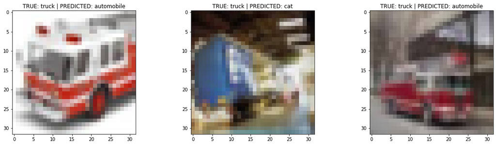

```python
# full code in notebooks
```

Przykłady poprawnych klasyfikacji dla każdej z klas:

[figure not shown]

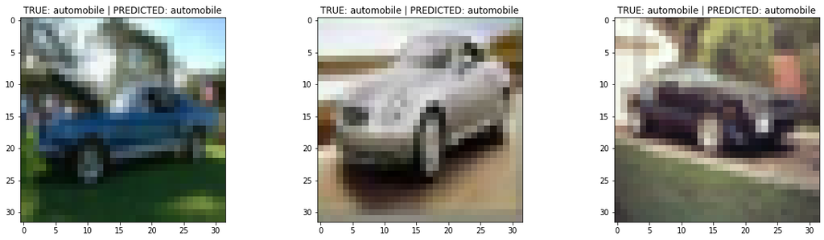

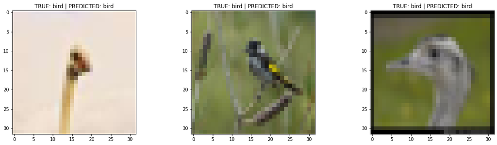

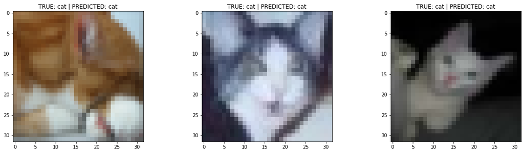

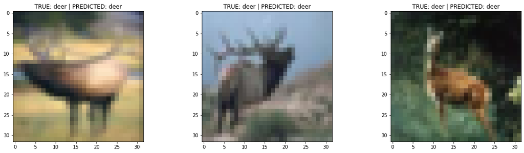

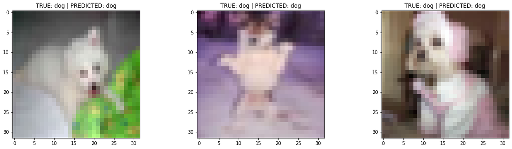

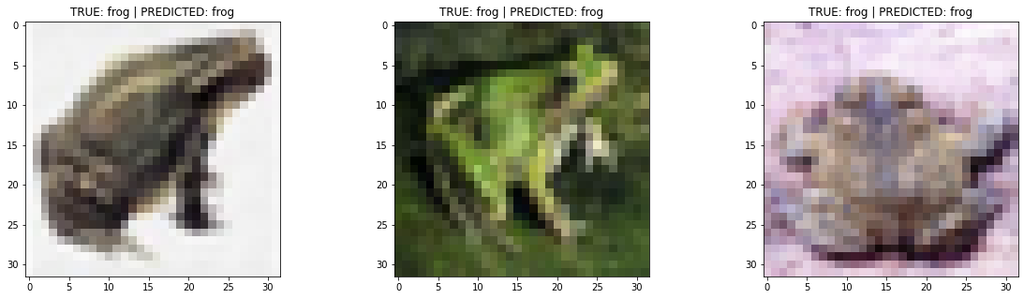

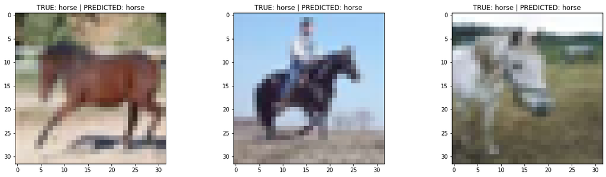

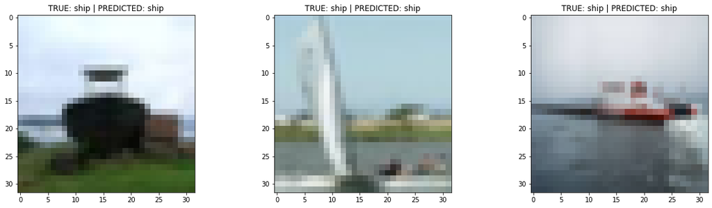

[figure not shown]

```python
# full code in notebooks
```

## Wnioski

- Zastosowanie techniki Dropout dało niewiele lepsze wyniki od modelu bazowego, a proces uczenia wygląda bardzo podobnie.
- Zastosowanie regularyzacji L1 i DepthWiseConv2D dało widoczny efekt regularyzji, ponieważ wyniki otrzymywane na zbiorze treningowym i walidacyjnym były zbliożone. Jednak ostatecznie modele te dały słabe wyniki, co może świadczyć, że zastosowana została zbyt duża regularyzacja.
- Można zauważyć, że model popełnia błędy w przypadku obiektów mających w rzeczywistości podobne cechy lub występujących w podobnym otoczeniu, jak np. pojazdy, zwierzęta. Ciekawym przykładem jest zaklasyfikowanie samolotu na zielonym tle jako żaby.
- Najwięcej klasyfikacji TP przypadło klasie *Automobile*, ale trzeba wziąć pod uwage, że jednocześnie do klasy tej została przypisana znacząca liczba obrazów z klasy *Truck*.
- Model najgorzej poradził sobie z klasami określającymi zwierzęta, a konkretnie: *bird*, *cat*, *deer*, *dog*